# Reproducible Research: Peer Assessment 1

First, setting the global option echo to TRUE, as required

```r
knitr::opts_chunk$set(echo = TRUE)
```

## Loading and preprocessing the data

```r
download.file("https://d396qusza40orc.cloudfront.net/repdata%2Fdata%2Factivity.zip"
              ,"archive.zip")
unzip("archive.zip")
activity<-read.csv("activity.csv")
```

## What is mean total number of steps taken per day?

First, we aggregate the data to sum the steps per day

```r
dailySteps<-aggregate(steps~date,activity,sum,na.action=na.omit)
```

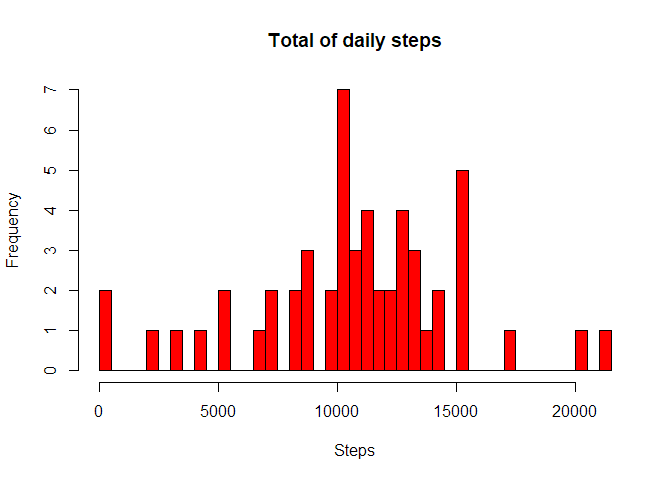

```r
hist(dailySteps$steps,breaks=nrow(dailySteps),main="Total of daily steps",xlab="Steps",col="red")
```

Finally, we calculate and report the mean and median of the total number of steps taken per day. The numbers are rounded so thay can be read more easily. We have to use the as.character() function because the display of the number is off when knitting.

```r
totalMean <- as.character(round(mean(dailySteps$steps),digits=0))
totalMedian <- as.character(round(median(dailySteps$steps),digits=0))
```

Mean: 10766  
Median: 10765

## What is the average daily activity pattern?

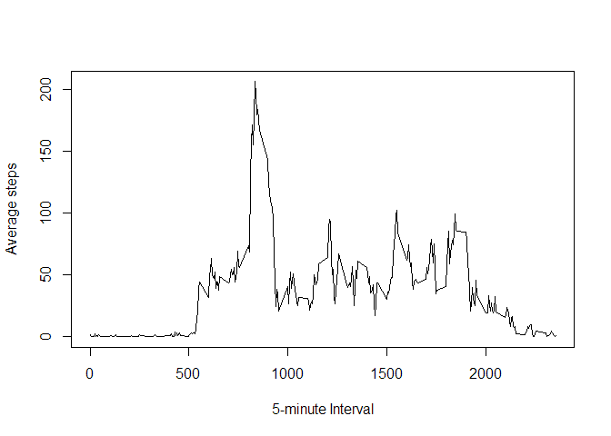

```r
intervalAvg <- aggregate(steps~interval,activity,mean,na.action=na.omit)
plot(intervalAvg$interval,intervalAvg$steps,type="l",xlab = "5-minute Interval"
     ,ylab = "Average steps" )
```

Which 5-minute interval, on average across all the days in the dataset, contains the maximum number of steps?

```r
maxInterval <- intervalAvg[intervalAvg$steps==max(intervalAvg$steps,
                                                  na.rm = TRUE),1]
```

The interval containing on average the maximum number of steps is : 835

## Imputing missing values

```r
NARows<- sum(is.na(activity$steps))
```

Number of NA rows: 2304

Imputing strategy: we will replace the NA values with the average (mean) for that interval.

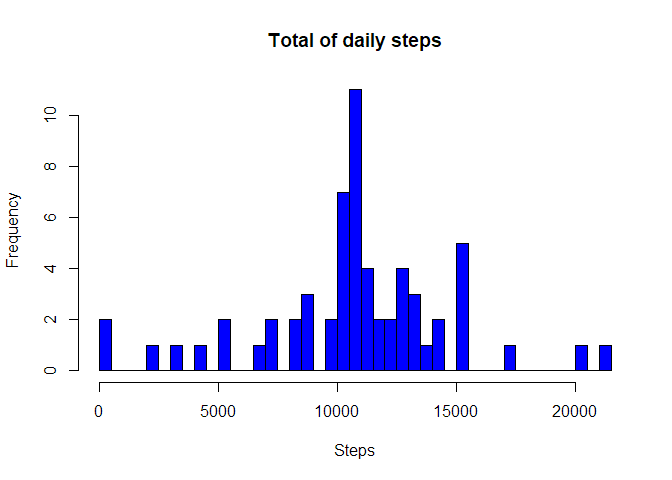

```r
activityImpute<-activity
activityImpute$steps[is.na(activity$steps)]<-
        intervalAvg$steps[match(intervalAvg$interval,activity$interval)]
dailyStepsImpute<-aggregate(steps~date,activityImpute,sum,na.action=na.omit)
hist(dailyStepsImpute$steps,breaks=nrow(dailyStepsImpute),main="Total of daily steps",xlab="Steps",col="blue")
```

```r
totalMeanImpute <- as.character(round(mean(dailyStepsImpute$steps),digits=0))
totalMedianImpute <- as.character(round(median(dailyStepsImpute$steps),
                                        digits=0))
```

Mean: 10766  
Median: 10766

## Are there differences in activity patterns between weekdays and weekends?

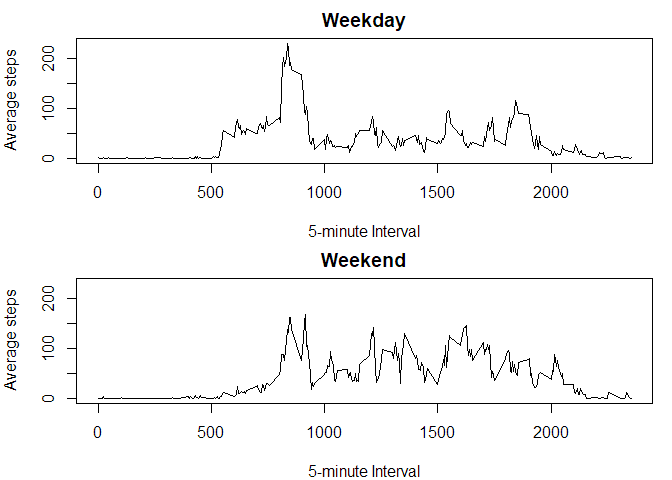

```r
activityImpute$dayType <- ifelse(as.POSIXlt(activityImpute$date)$wday %in%
                                         c(0,6), 'weekend', 'weekday')
activityImpute$dayType <- factor(activityImpute$dayType)
intervalAvgImpute <- aggregate(steps ~ interval + dayType, data=activityImpute, mean)
par(mfrow=c(2,1), mar = c(4, 4, 2, 1))

YMax <- max(intervalAvgImpute$steps)
XMax <- max(activityImpute$interval)

plot(intervalAvgImpute$interval[intervalAvgImpute$dayType=="weekday"],
     intervalAvgImpute$steps[intervalAvgImpute$dayType=="weekday"],type="l",
     xlab = "5-minute Interval",ylab = "Average steps",xlim=c(0,XMax),ylim=c(0,YMax),main = "Weekday")

plot(intervalAvgImpute$interval[intervalAvgImpute$dayType=="weekend"],
     intervalAvgImpute$steps[intervalAvgImpute$dayType=="weekend"],type="l",
     xlab = "5-minute Interval",ylab = "Average steps",xlim=c(0,XMax),ylim=c(0,YMax),main = "Weekend")
```